# Final_Report

```r
# Participants are mostly around 64-69 inches
```

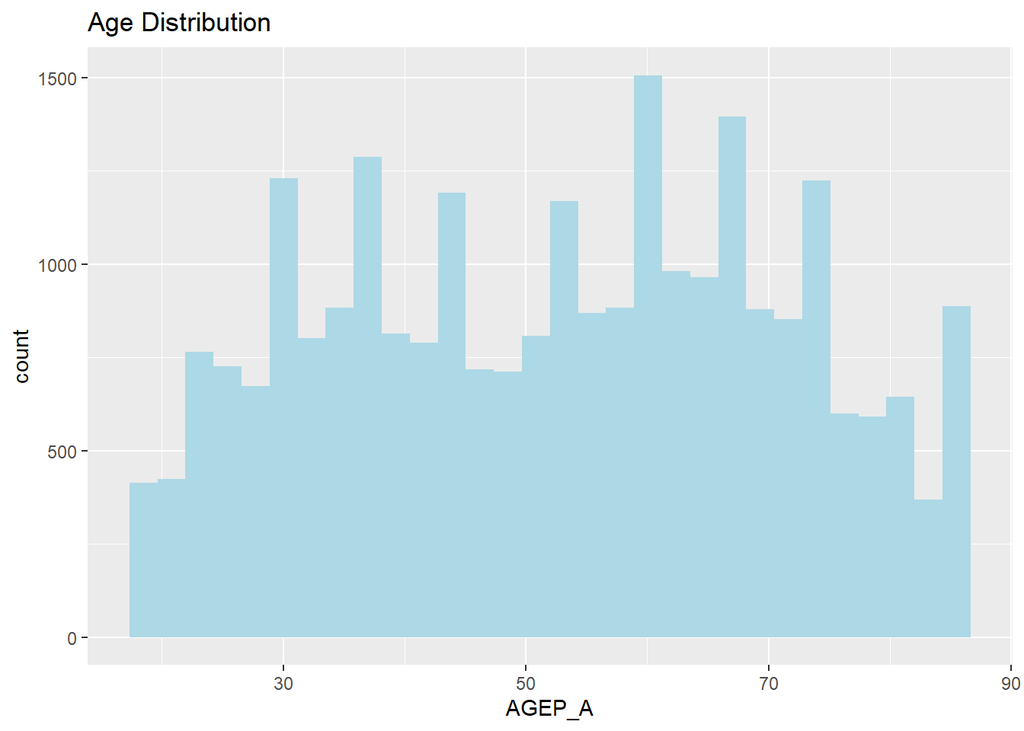

```r
# Ggplot2 histogram

ggplot(nhis_clean, aes(x = AGEP_A)) +
  geom_histogram(bins = 30, fill = "lightblue") +
  ggtitle("Age Distribution")
```

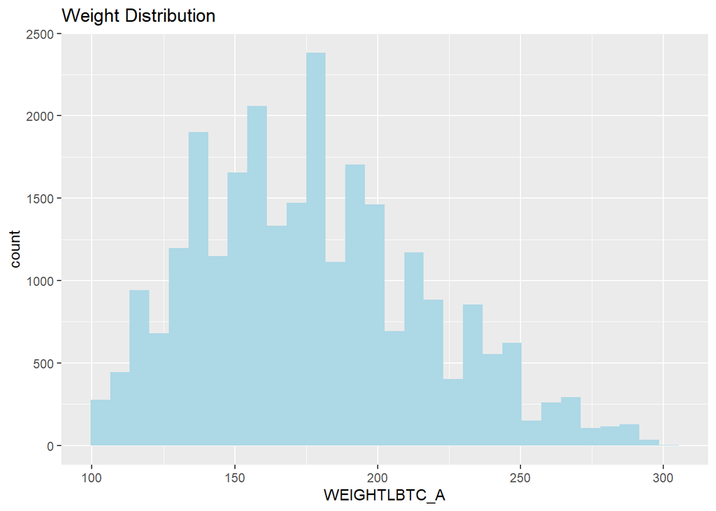

```r
# Participants age is spread across 20-80 years old

ggplot(nhis_clean, aes(x = WEIGHTLBTC_A)) +
  geom_histogram(bins = 30, fill = "lightblue") +
  ggtitle("Weight Distribution")
```

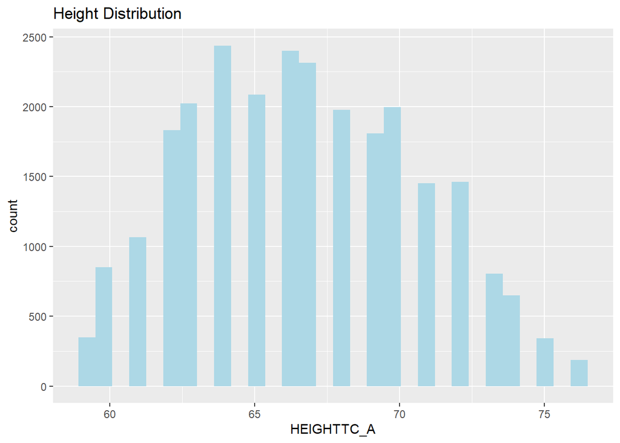

```r
# Most participants are 140-200 pounds, but participants go up to 300 pounds

ggplot(nhis_clean, aes(x = HEIGHTTC_A)) +
  geom_histogram(bins = 30, fill = "lightblue") +
  ggtitle("Height Distribution")
```

```r
# Most participants are around 65-70 inches
```

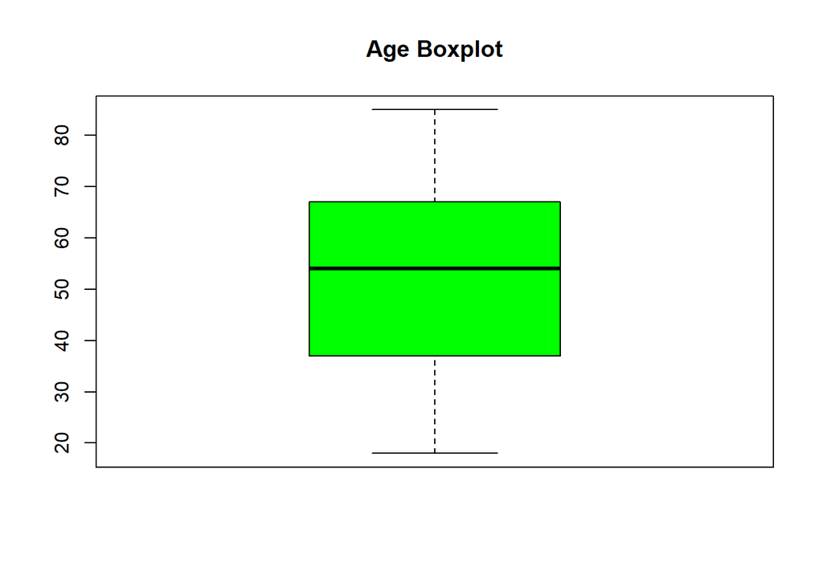

```r
# Base R Boxplot

boxplot(nhis_clean$AGEP_A,
        main = "Age Boxplot",
        col = "green")
```

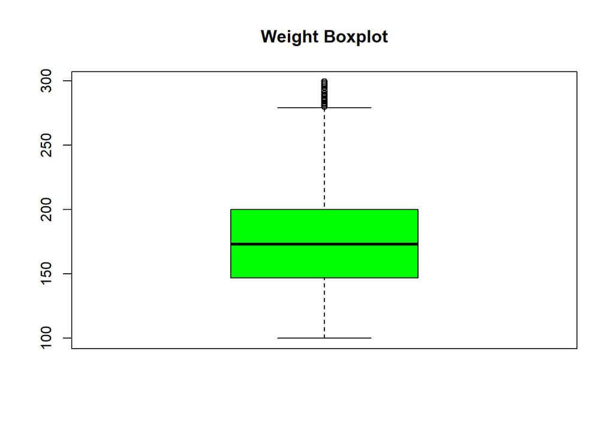

```r
# Average age of participants is around 55 years old

boxplot(nhis_clean$WEIGHTLBTC_A,
        main = "Weight Boxplot",
        col = "green")
```

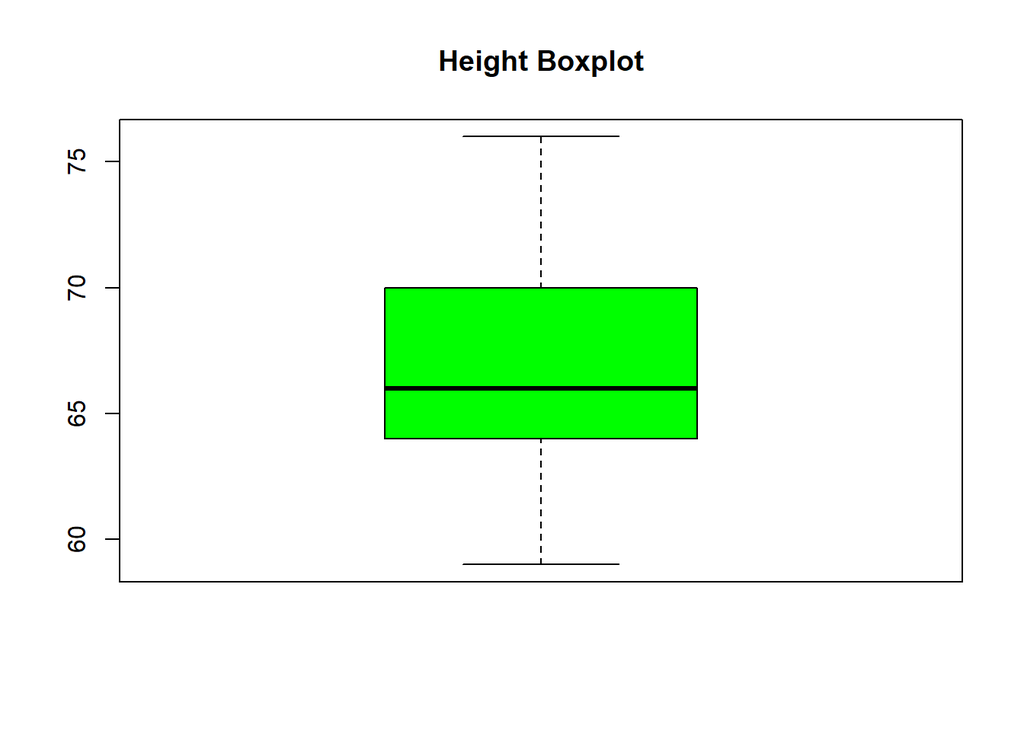

```r
# Average weight of participants is about 175 pounds

boxplot(nhis_clean$HEIGHTTC_A,
        main = "Height Boxplot",
        col = "green")
```

```r
# Average height of participants are about 66 inches
```

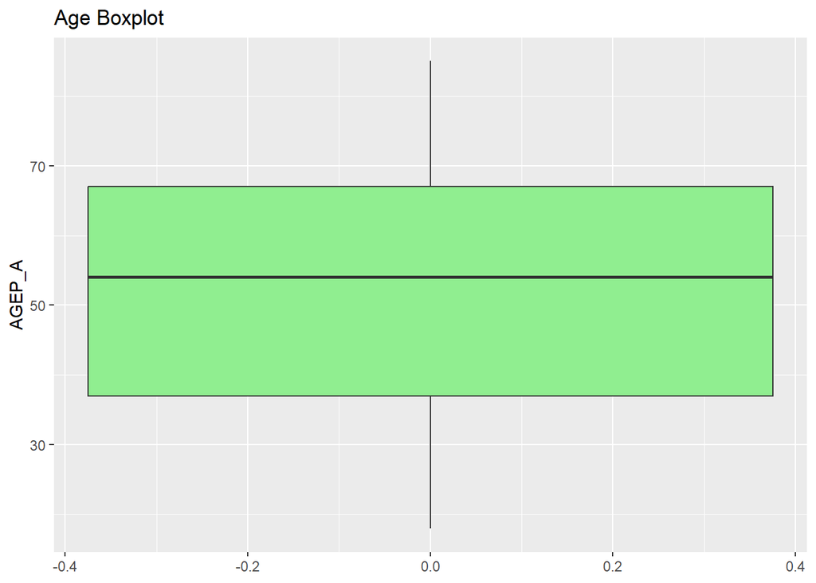

```r
# ggplot2 boxplots

ggplot(nhis_clean, aes(y = AGEP_A)) +
  geom_boxplot(fill = "lightgreen") +
  ggtitle("Age Boxplot")
```

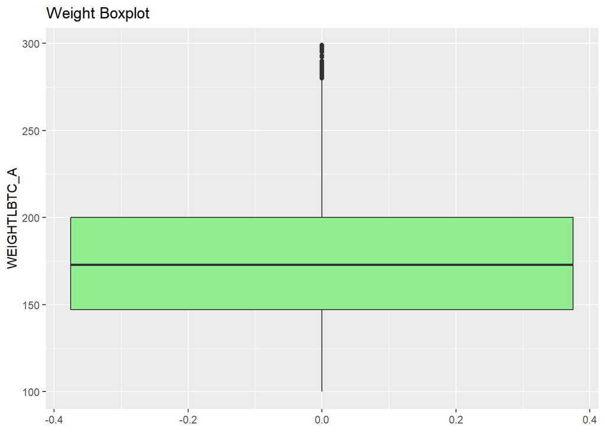

```r
# Average age of participants is 54 years old

ggplot(nhis_clean, aes(y = WEIGHTLBTC_A)) +
  geom_boxplot(fill = "lightgreen") +
  ggtitle("Weight Boxplot")
```

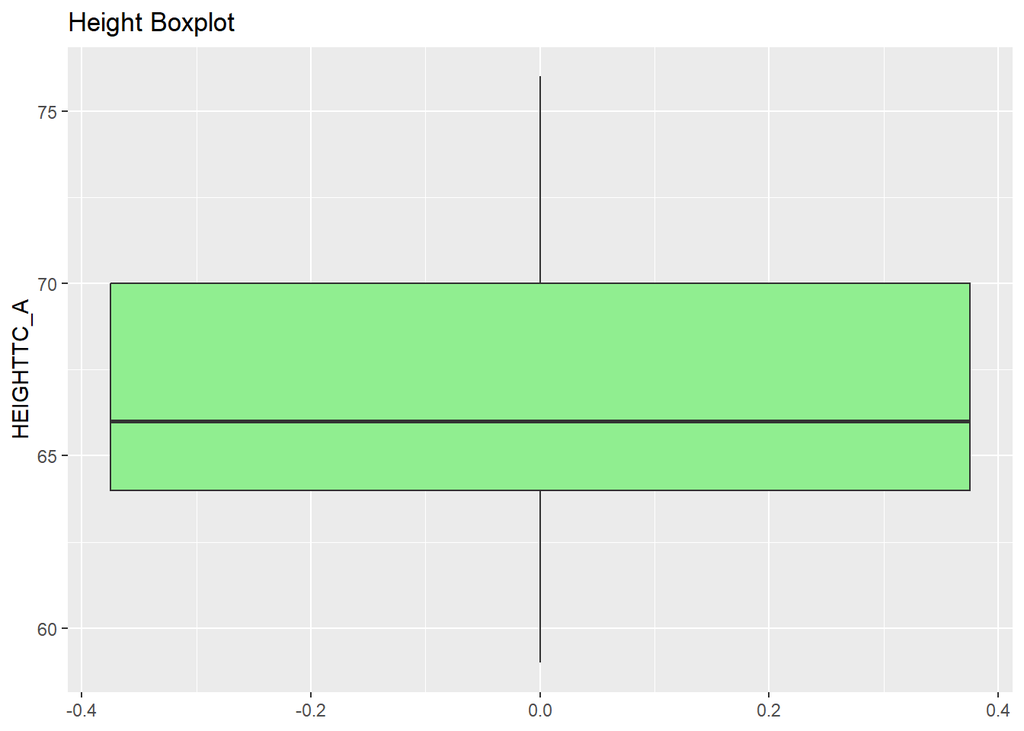

```r
# Average weight of participants is 174 lbs

ggplot(nhis_clean, aes(y = HEIGHTTC_A)) +
  geom_boxplot(fill = "lightgreen") +
  ggtitle("Height Boxplot")
```

```r
# Average participants height is 66 inches
```

### Interpretation

The summary statistics and visualizations for the quantitative variables reveal a diverse adult population with expected physiological ranges.

Weight(WEIGHTLBTC_A): Participants’ weights range from 100 to 299 pounds, with a mean weight of 176.8 pounds. Both the histograms and boxplots illustrate that the majority of the population is concentrated between 140 and 200 pounds. The boxplot highlights that while the distribution is centered around the median of 173 lbs, there is a notable spread toward the upper weight limit.

Height(HEIGHTTC_A): The height distribution is approximately normal, centered around a mean of 66.7 inches, or roughly 5’7”. The narrow standard deviation at 3.9 inches and the boxplot indicate that most participants are between 64 and 70 inches tall.

### Qualitative Variables

```r
# Frequency tables and graphs for qualitative variables

# 1. SEX_A

table(nhis_clean$SEX_A)
```

```
##
##     1     2
## 11967 14070
```

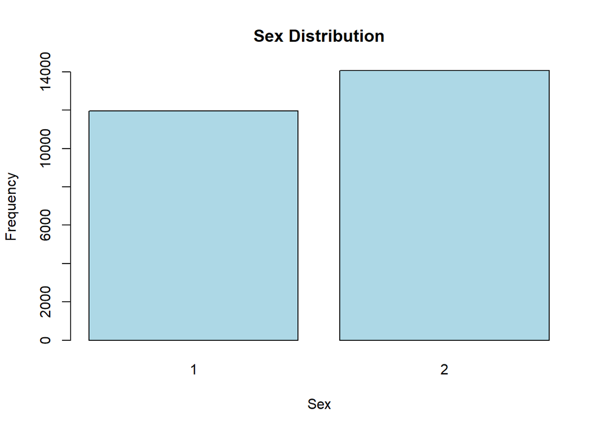

```r
barplot(table(nhis_clean$SEX_A),
        main = "Sex Distribution",
        xlab = "Sex",
        ylab = "Frequency",
        col = "lightblue")
```

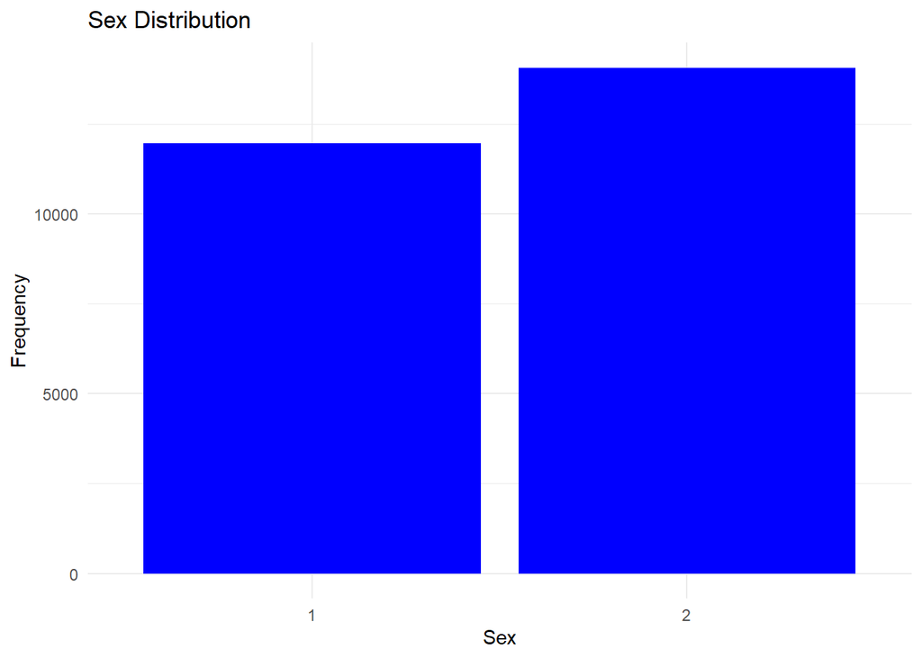

```r
ggplot(nhis_clean, aes(x = factor(SEX_A))) +
  geom_bar(fill = "blue") +
  labs(title = "Sex Distribution",
       x = "Sex",
       y = "Frequency") +
  theme_minimal()
```

```r
# 2. HISPALLP_A

table(nhis_clean$HISPALLP_A)
```

```
##
##     1     2     3     4     5     6     7
##  3533 17617  2645  1564   153   196   329
```

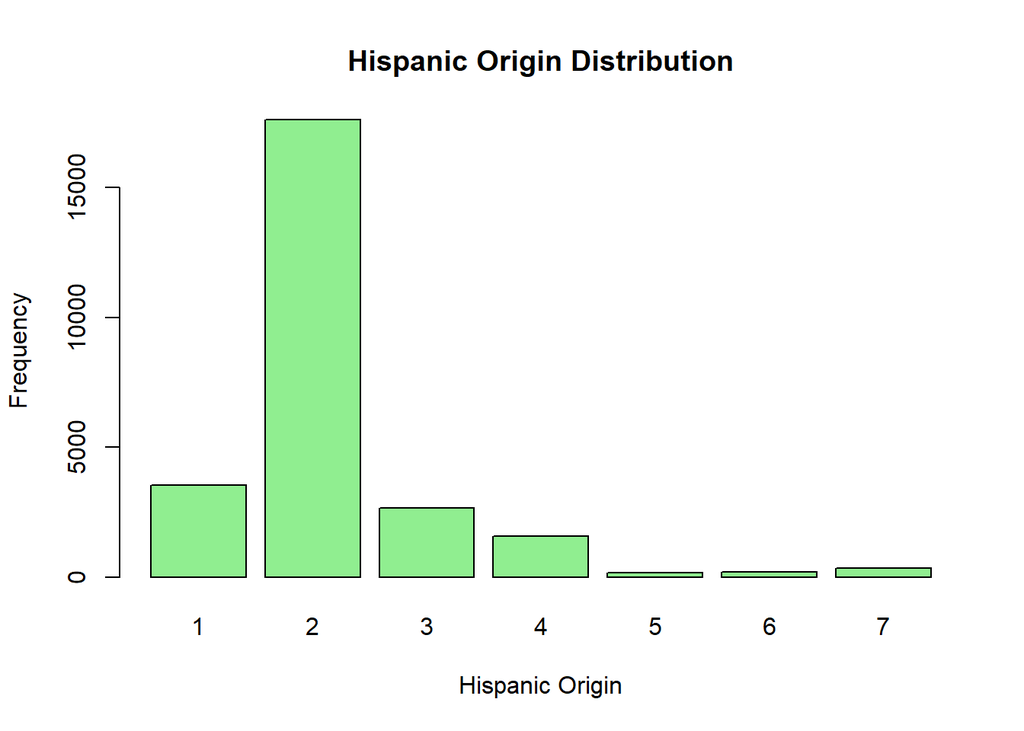

```r
barplot(table(nhis_clean$HISPALLP_A),
        main = "Hispanic Origin Distribution",
        xlab = "Hispanic Origin",
        ylab = "Frequency",
        col = "lightgreen")
```

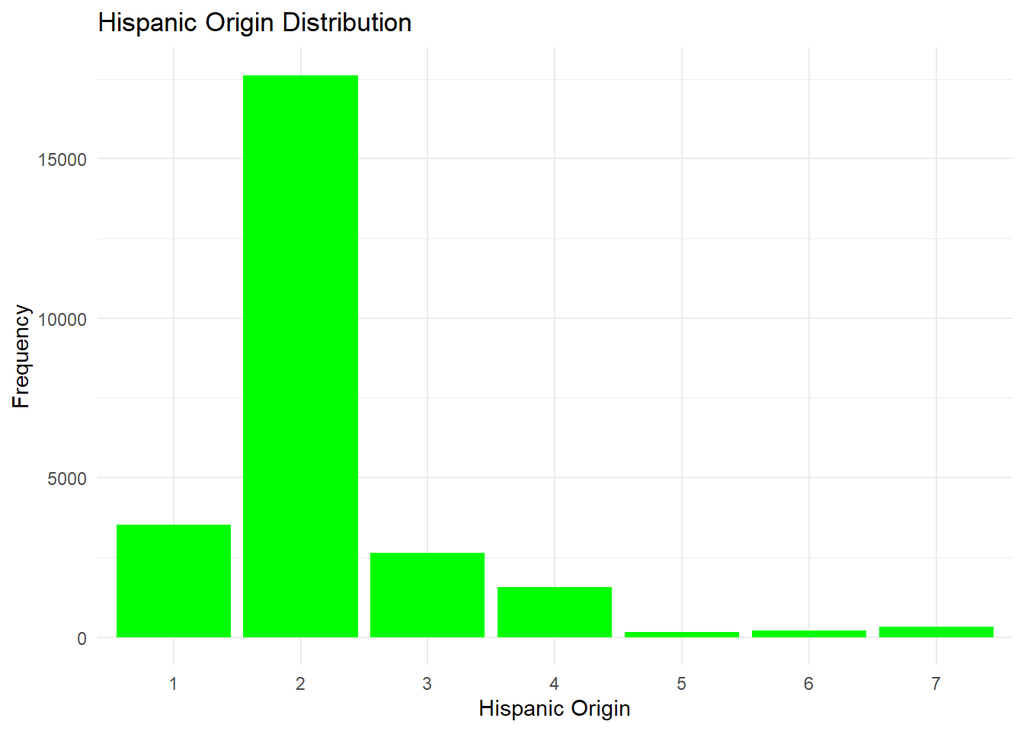

```r
ggplot(nhis_clean, aes(x = factor(HISPALLP_A))) +
  geom_bar(fill = "green") +
  labs(title = "Hispanic Origin Distribution",
       x = "Hispanic Origin",
       y = "Frequency") +
  theme_minimal()
```

```r
# 3. EDUCP_A
table(nhis_clean$Education)
```

```
##
##      less than High School       High School Graduate
##                       2676                       5765
##     Some College Education College Graduate or better
##                       7238                      10358
```

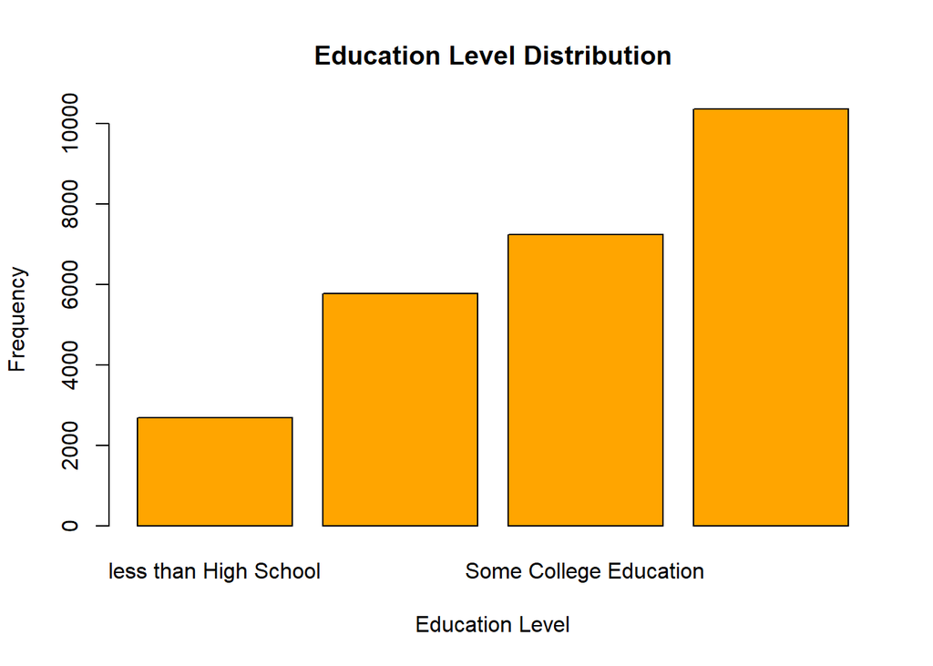

```r
barplot(table(nhis_clean$Education),
        main = "Education Level Distribution",
        xlab = "Education Level",
        ylab = "Frequency",
        col = "orange")
```

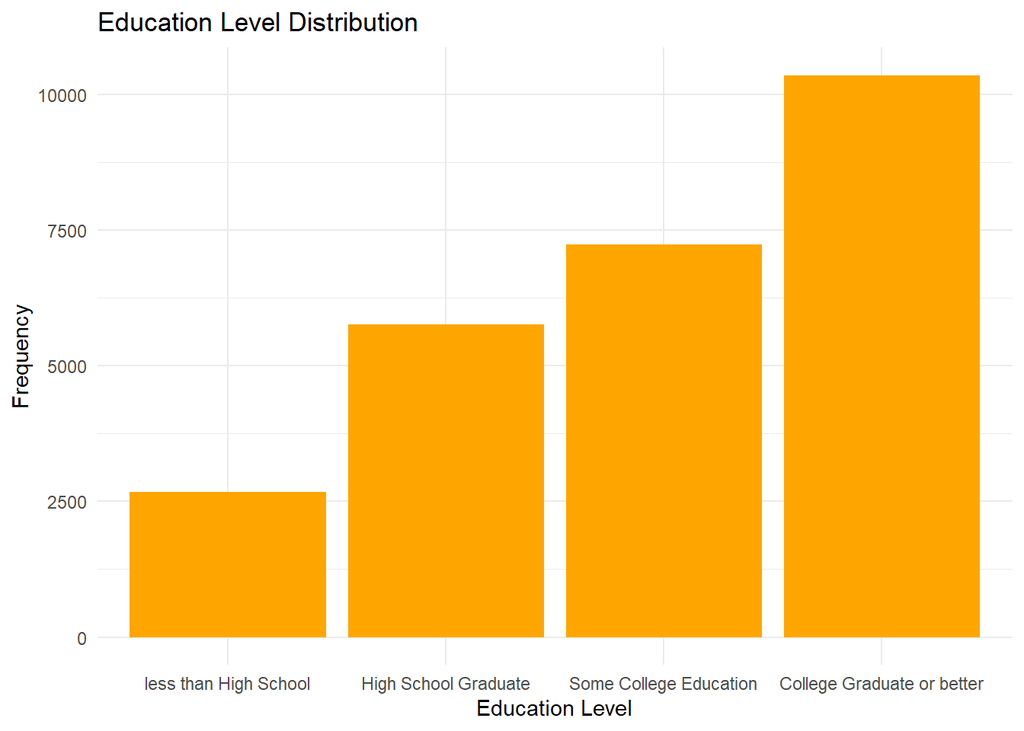

```r
ggplot(nhis_clean, aes(x = Education)) +
  geom_bar(fill = "orange") +
  labs(title = "Education Level Distribution",
       x = "Education Level",
       y = "Frequency") +
  theme_minimal()
```

```r
# 4. PHSTAT_A
table(nhis_clean$PHSTAT_A)
```

```
##
##    1    2    3    4    5
## 6065 9185 7287 2717  783
```

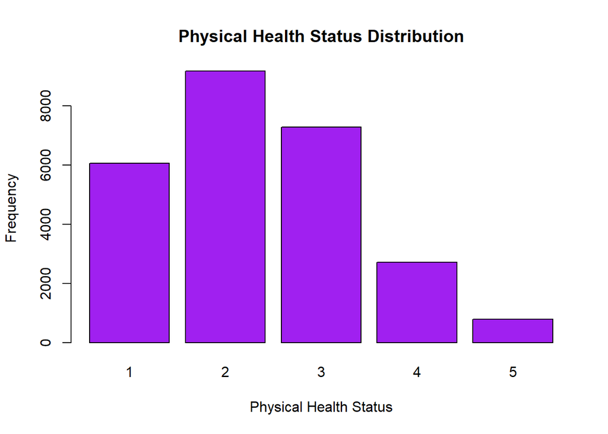

```r
barplot(table(nhis_clean$PHSTAT_A),
        main = "Physical Health Status Distribution",
        xlab = "Physical Health Status",
        ylab = "Frequency",
        col = "purple")
```

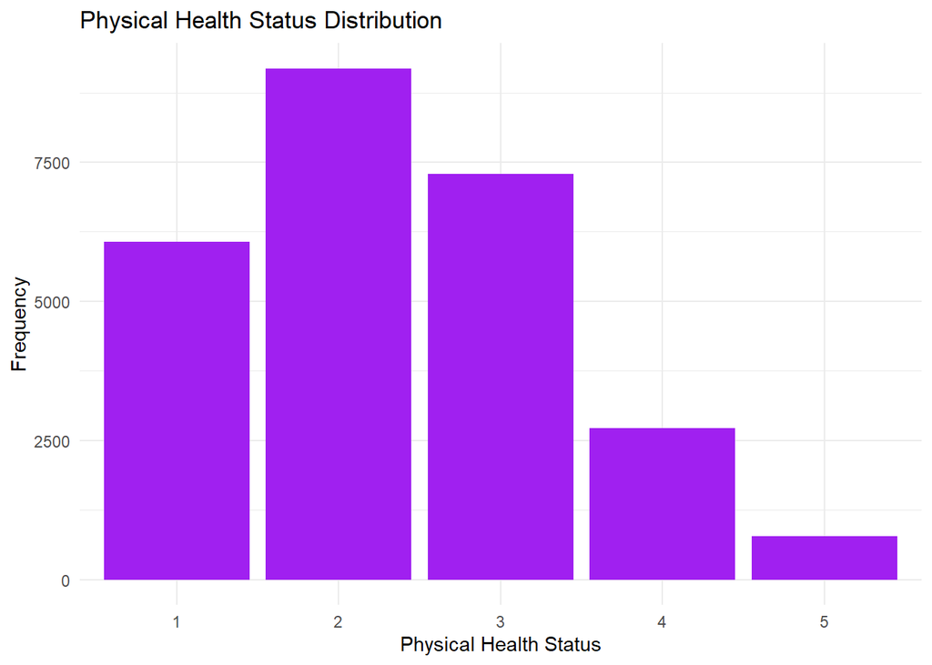

```r
ggplot(nhis_clean, aes(x = factor(PHSTAT_A))) +
  geom_bar(fill = "purple") +
  labs(title = "Physical Health Status Distribution",
       x = "Physical Health Status",
       y = "Frequency") +
  theme_minimal()
```

```r
# 5. LSATIS4R_A
table(nhis_clean$LSATIS4R_A)
```

```
##
##     1     2     3     4
## 12458 12266  1025   288
```

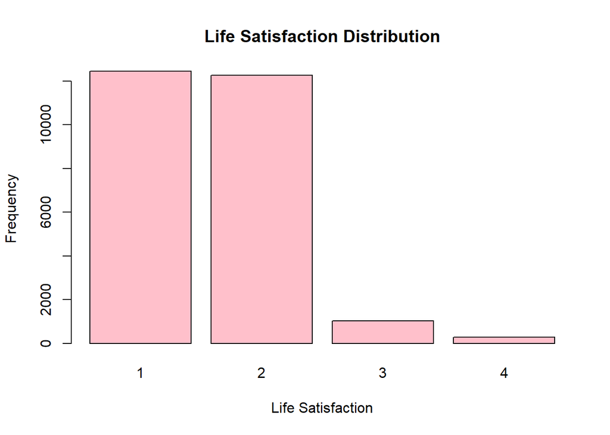

```r
barplot(table(nhis_clean$LSATIS4R_A),
        main = "Life Satisfaction Distribution",
        xlab = "Life Satisfaction",
        ylab = "Frequency",
        col = "pink")
```

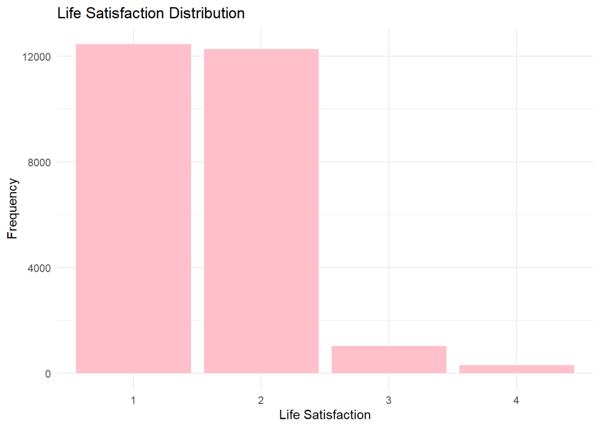

```r
ggplot(nhis_clean, aes(x = factor(LSATIS4R_A))) +
  geom_bar(fill = "pink") +
  labs(title = "Life Satisfaction Distribution",
       x = "Life Satisfaction",
       y = "Frequency") +
  theme_minimal()
```

### Interpretation

Frequency tables and bar plots were used to assess the distribution of categorical variables. These distributions provide context for the social and health-related tiers of the sample.

Sex(SEX_A): The frequency table and bar plots indicate that Females (“2”) make up a slight majority of the sample, providing a relatively even basis for gender-based health comparisons.

Hispanic Origin(HISPALLP_A): The bar chart reveals that a large majority of participants identify as Non-Hispanic White (n = 17,617), followed by Hispanic (n =3,533). This distribution is crucial for identifying potential health disparities across different racial and ethnic groups in the subsequent analysis.

Education Level(Education): Based on the recoded variable, the largest segment of our population consists of “College Graduates or better”. This highlights the socioeconomic diversity of the sample and serves as a primary independent variable for analyzing health status.

Physical Health Status(PHSTAT_A): The distribution of general health status is skewed toward the “Very Good” (2) categories, followed by “Good”, and then “Excellent.” This suggests that a significant portion of the cohort perceives their physical health as positive, though a smaller frequency remains in the “Fair” and “Poor” categories.

Life Satisfaction(LSATIS4R_A): Life satisfaction plots show that most participants reported being “Very Satisfied” (1) and “Satisfied” (2). Understanding the frequency of these subjective well-being scores is essential for exploring the relationship between mental outlook and physical health outcomes.

The univariate analysis confirms that the cleaned dataset is free from the extreme outliers identified during the inital exploration. The cohort is primarily composed of middle-aged adults with a broad range of educational backgroynds and generally positive self-reported health and life satisfaction. These distributions provide the necessary context to move forward with bivariate analysis to see how these variables interact.

## Task 2: Bivariate Analysis

The bivariate analysis explores the relationships between pairs of variables to identify patterns, differences, and correlations within the NHIS 2021 cohort. By examining how quantitative measures vary across qualitative categories, and how two quantitative measures interact, we gain deeper insight into the health profile of this sample.

### Quantitative vs Qualitative Boxplots

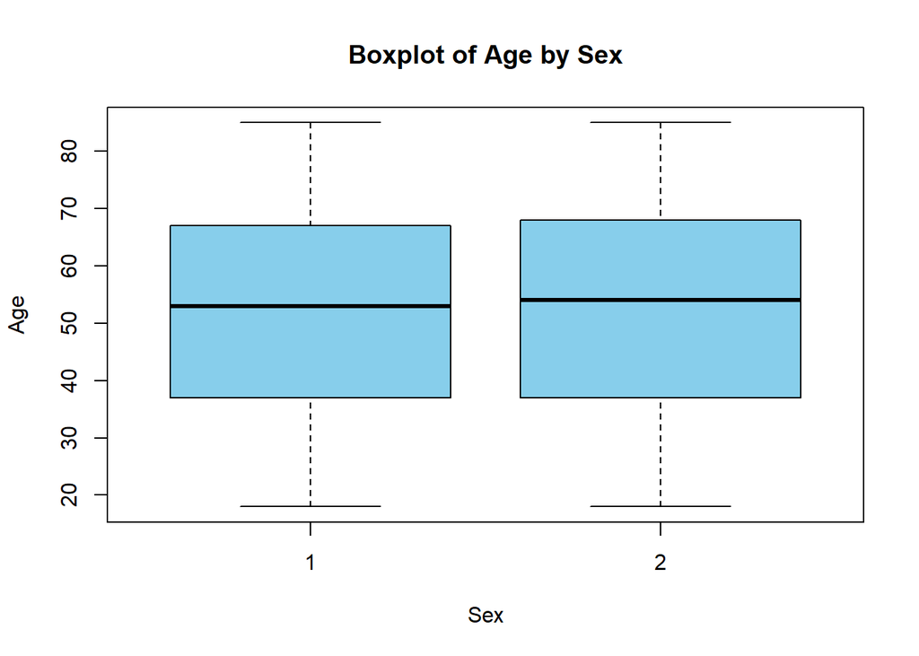

```r
# Creating boxplots for AGEP_A and to display levels by SEX_A and EDUCP_A

boxplot(AGEP_A ~ factor(SEX_A), data = nhis_clean,
        main="Boxplot of Age by Sex",
        xlab = "Sex",
        ylab= "Age",
        col= "skyblue",
        border="black")
```

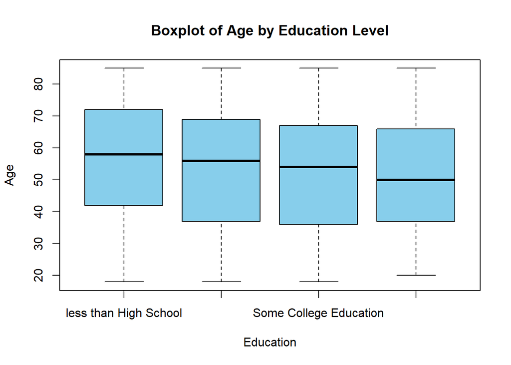

```r
boxplot(AGEP_A ~ Education, data = nhis_clean,
        main= "Boxplot of Age by Education Level",
        xlab = "Education",
        ylab = "Age",
        col= "skyblue",
        border= "black")
```

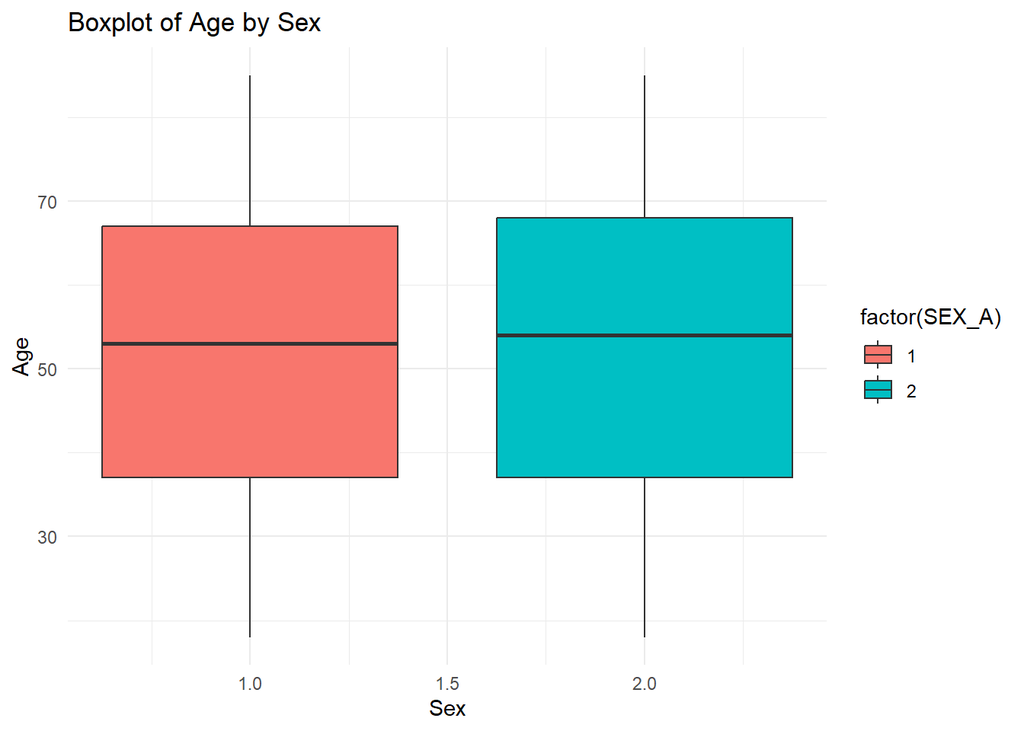

```r
ggplot(nhis_clean, aes(x=SEX_A, y=AGEP_A))+
  geom_boxplot(aes(fill = factor(SEX_A)))+
  labs(title = "Boxplot of Age by Sex",
       x= "Sex",
       y= "Age")+
  theme_minimal()
```

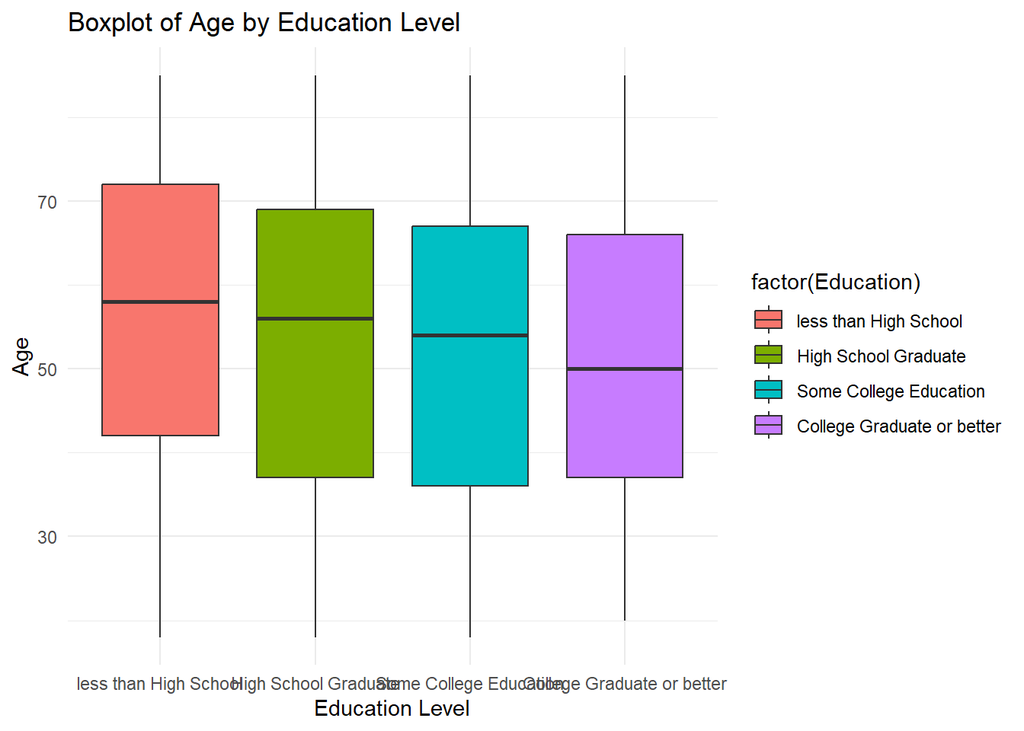

```r
ggplot(nhis_clean, aes(x=Education, y=AGEP_A))+
  geom_boxplot(aes(fill = factor(Education)))+
  labs(title = "Boxplot of Age by Education Level",
       x= "Education Level",
       y= "Age")+
  theme_minimal()
```

### Quantitative vs Qualitative Clustered Bar Chart

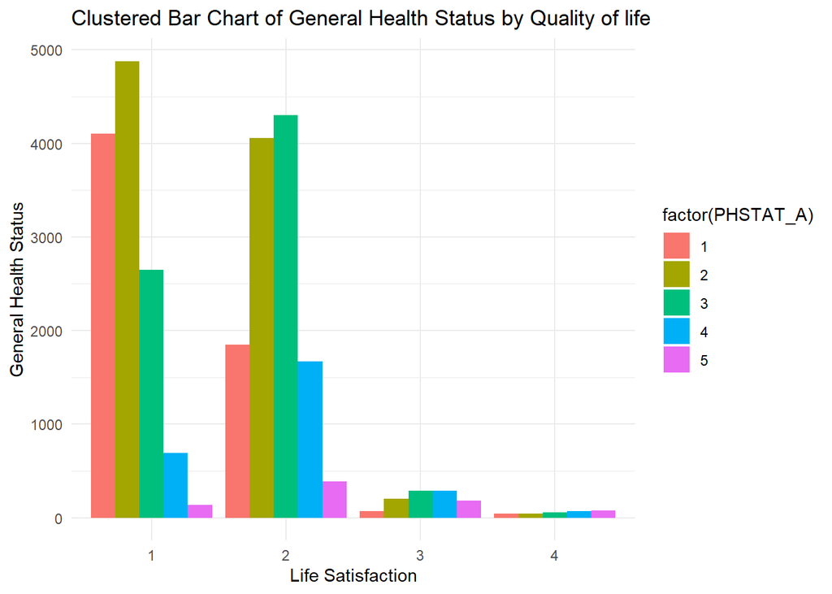

```r
# Creating clustered bar chart for PHSTAT_A (General Health) by LSATIS4R_A (Life Satisfaction)

ggplot(nhis_clean, aes(x=factor(LSATIS4R_A), fill= factor(PHSTAT_A)))+
  geom_bar(position = "dodge")+
  labs(title = "Clustered Bar Chart of General Health Status by Quality of life",
       x="Life Satisfaction",
       y="General Health Status")+
    theme_minimal()
```

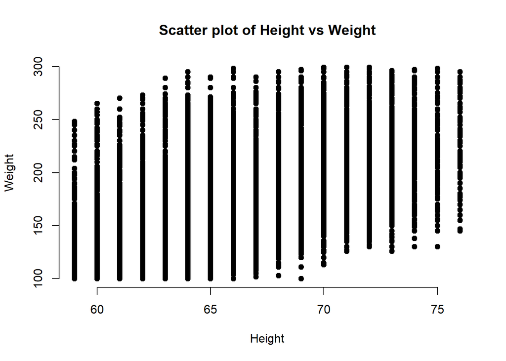

```r
# Creating a scatter plot for HEIGHTTC_A and WEIGHTLBTC_A

x <- nhis_clean$HEIGHTTC_A
y <- nhis_clean$WEIGHTLBTC_A

plot(x,y,
     main="Scatter plot of Height vs Weight",
     xlab = "Height",
     ylab= "Weight",
     pch = 19, frame = FALSE)
```

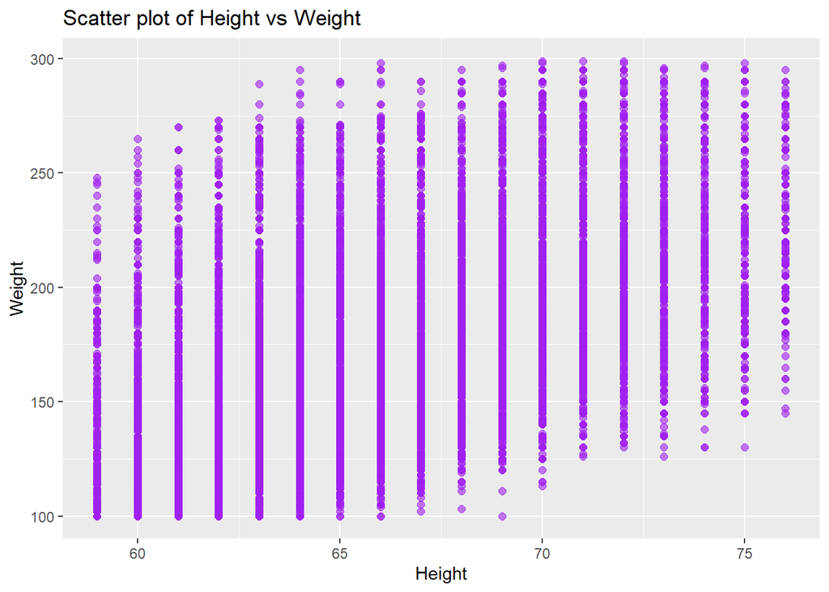

```r
ggplot(nhis_clean,
       aes(x = HEIGHTTC_A, y = WEIGHTLBTC_A))+
  geom_point(color="purple",
             size= 2,
             alpha=.6)+
  labs(title = "Scatter plot of Height vs Weight",
       x= "Height",
       y= "Weight")
```

```r
# Correlation report Height vs Weight
# This report shows that there is a significant relationship p-value<2.2e-16, because we reject the null hypothesis.

cor.test(nhis_clean$HEIGHTTC_A,nhis_clean$WEIGHTLBTC_A)
```

```
##
##  Pearson's product-moment correlation
##
## data:  nhis_clean$HEIGHTTC_A and nhis_clean$WEIGHTLBTC_A
## t = 93.731, df = 26035, p-value < 2.2e-16
## alternative hypothesis: true correlation is not equal to 0
## 95 percent confidence interval:
##  0.4931660 0.5113306
## sample estimates:
##       cor
## 0.5023037
```

### Interpretation

Side-by-side boxplots were utilized to visualize how age is distributed across different demographic groups. The distribution of age appears similar between males and females. The median age for both groups remains near the mid-50’s, suggesting that gender does not significantly skew the age profile of this specific cohort. The boxplots also visualize age across the four recoded educational levels: less than High School, High School Graduate, Some College Education, and College Graduate or better. The “less than High School” group appears to have a slightly higher median age, which likely reflects broader historical shifts in education access, where older generations were less likely to obtain high school diplomas or college degrees compared to younger cohorts.

The clustered bar chart was employed to examine the relationship between a participant’s perceived physical health status (PHSTAT_A) and their reported life satisfaction (LSATIS4R_A). The visualization shows a clear positive association between physical health and mental well-being. Participants who reported being “Very Satisfied (1) were predominantly represented in the”Excellent” (1) and “Very Good” (2) health categories, with very few reporting poor health. Lower levels of satisfaction shifts the modal health response towards “Good” (3), “Fair” (4), and “Poor” (5). This suggests that high life satisfaction may act as a protective factor or a marker for overall physical resilience. The dissatisfied individuals highlight a vulnerable population that may face a double burden of both physical ailment and lower psychological well-being.

To assess the relationship between physical measurements, a scatter plot and a Pearson correlation test were conducted for height (HEIGHTTC_A) and weight (WEIGHTLBTC_A). The scatter plot demonstrates a clear positive linear trend, indicating that as height increases, weight generally tends to increase as well. The vertical strips in the plot reflect that height was recorded in whole-inch increments, ranging from 59 to 76 inches. The correlation analysis yielded a p-value of < 2.2 * 10^-16, which is far below the standard significance threshold of 0.05. This highly significant result allows us to reject the null hypothesis and confirm a genuine relationship between these variables in the NHIS population. The calculated Pearson’s r is 0.502, indicating a moderate-to-strong positive correlation. This means that approximately 25% (r^2 = 0.25) of the variation in weight can be explained by height alone.

The bivariate results highlight critical associations. While age remains stable across sex, it varies by educational attainment due to generational trends. Most notable, the data confirms a strong link between physical health and life satisfaction, alongside a highly significant correlation (r = 0.502) between height and weight. These findings provide the groundwork for multivariate analysis, where we will see if these patterns hold when considering multiple factors simultaneously.

# Day 4: Multivariate Analysis

## Enhanced Scatterplot

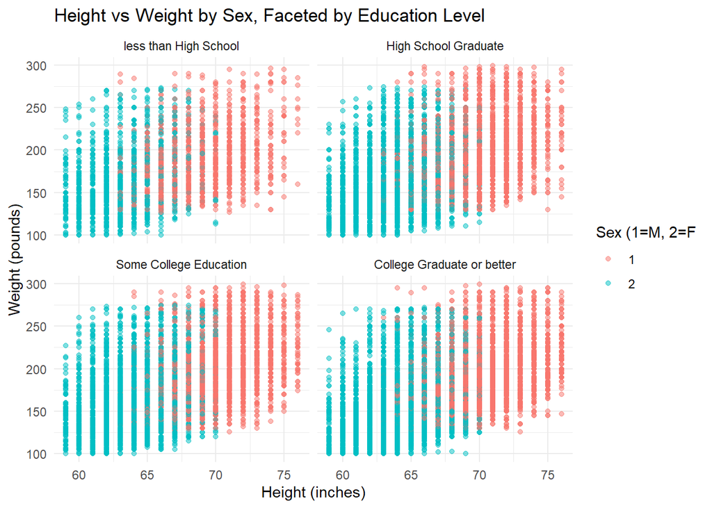

```r
# Use ggplot2 to enhance the Day 3 Scatterplot
ggplot(nhis_clean, aes(x = HEIGHTTC_A, y = WEIGHTLBTC_A, color = factor(SEX_A))) +
  geom_point(alpha = 0.5) +
  facet_wrap(~ Education) +
  labs(title = "Height vs Weight by Sex, Faceted by Education Level",
       x = "Height (inches)",
       y = "Weight (pounds)",
       color = "Sex (1=M, 2=F") +
  theme_minimal()
```

### Correlation Scatter Plot Matrix

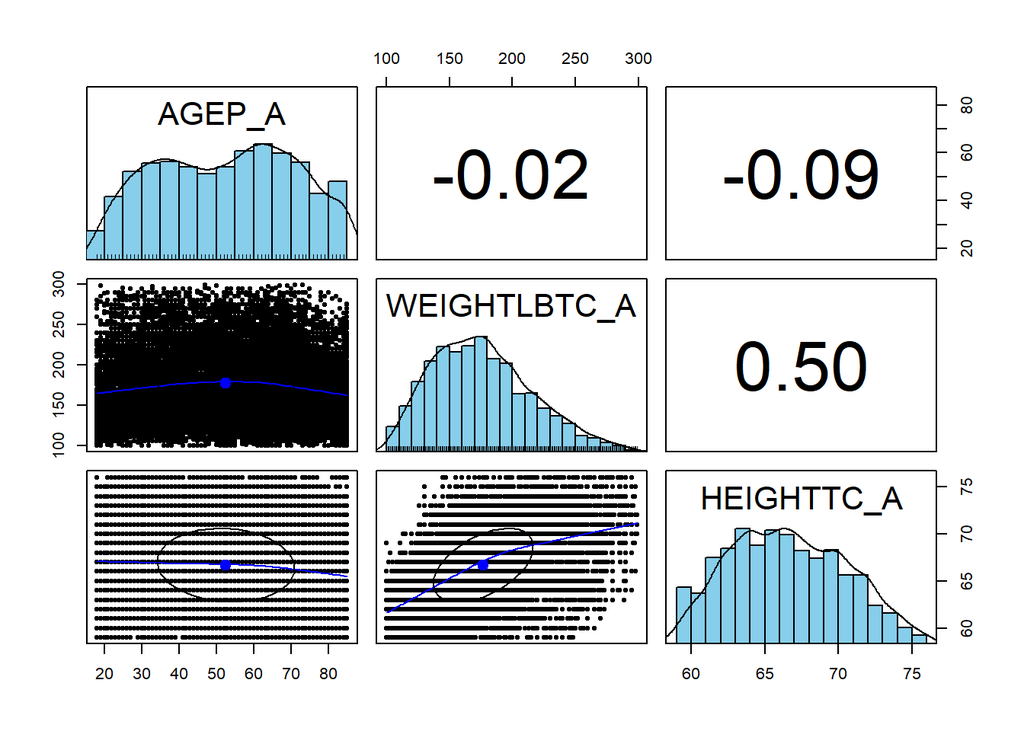

```r
# Use pairs.panels() to create a correlation matrix
# Select only the quantitative variables for the matrix
quant_vars <- nhis_clean %>%
  select(AGEP_A, WEIGHTLBTC_A, HEIGHTTC_A)

pairs.panels(quant_vars,
             method = "pearson",
             hist.col = "skyblue",
             density = TRUE,
             ellipses = TRUE)
```

### Interpretation

The enhanced scatter plot uses color and faceting to visualize complex interactions between physiological and sociodemographic variables. The color coding reveals a distinct biological clustering. Males (1) generally occupy the higher end of both the height and weight axes, while Females (2) are concentrated at lower heights and weights. Despite the clustering, the positive correlation between height and weight remains consistent across both sexes. Faceting the plot by the four recoded education tiers demonstrates that the fundamental relationship between height and weight is stable regardless of socioeconomic status. The scatter plot suggests that while socioeconomic factors like education might influence health outcomes, the biological correlation between height and weight is a universal trend across this NHIS cohort. The density of the “College Graduate or better” facet also reflects the relatively high educational attainment of this specific sample.

The final step in this analysis is to use a correlation scatter plot matrix to examine all the relationships between Age, Weight, and Height.

Height and Weight (r = 0.50): Height and weight have the strongest relationship in the matrix. The scatter plot shows a clear positive slope, and the Pearson correlation coefficient of 0.50 confirms a moderate-to-strong link between the two.

Age and Weight (r = -0.02): The correlation coefficient is nearly zero, and the scatter plot shows a horizontal line. This suggests that in this specific 2021 cohort, age is not a meaningful predictor of weight. Weight remains relatively stable across different age groups.

Age and Height (r = -0.09) There is a very weak negative correlation. This may reflect a slight trend where older participants are marginally shorter on average, potentially due to natural age-related changes or generational differences in average height.

The diagonal histograms show that while Age is fairly even spread across the adult lifespan, weight is slightly right-skewed, and height follows a nearly normal, “bell-shaped” distribution.